# Topic Modeling in R: Latent Dirichlet Allocation

Data Science Analysis

2025-10-03

# Introduction

This document demonstrates **Topic Modeling** using **Latent Dirichlet Allocation (LDA)** in R. We will analyze a synthetic dataset about Australia to discover hidden topics and patterns in the text data.

## What is Topic Modeling?

Topic modeling is an unsupervised machine learning technique that automatically discovers abstract topics in a collection of documents. It helps us understand the main themes and concepts present in large text corpora without prior knowledge of the content.

## Latent Dirichlet Allocation (LDA)

LDA is one of the most popular topic modeling algorithms. It assumes that: - Each document is a mixture of topics - Each topic is a mixture of words - Documents are generated by sampling topics and then sampling words from those topics

# Dataset Overview

```
## Dataset files:
```

```
## 1 . australian_animals.txt
## 2 . australian_cities.txt
## 3 . australian_culture.txt
## 4 . australian_food.txt
## 5 . australian_landmarks.txt
## 6 . australian_sports.txt
```

# Data Loading and Preprocessing

```r
# Load required libraries
library(tm)
library(topicmodels)
library(tidytext)
library(dplyr)
library(ggplot2)
library(wordcloud)
library(RColorBrewer)
library(SnowballC)
```

```r
# Load the Australia dataset
data_dir <- "Australia-Dataset/"

# Read all text files into a corpus
corpus <- VCorpus(DirSource(data_dir), readerControl = list(language = "en"))

# Display basic information
cat("Number of documents:", length(corpus), "\n")
```

```
## Number of documents: 7
```

```r
cat("Document names:", names(corpus), "\n")
```

```
## Document names: australian_animals.txt australian_cities.txt australian_culture.txt australian_food.txt australian_landmarks.txt australian_sports.txt README.md
```

```r
# Preprocess the text
corpus_clean <- tm_map(corpus, content_transformer(tolower))
corpus_clean <- tm_map(corpus_clean, removePunctuation)
corpus_clean <- tm_map(corpus_clean, removeNumbers)
corpus_clean <- tm_map(corpus_clean, removeWords, stopwords("english"))
corpus_clean <- tm_map(corpus_clean, stripWhitespace)
corpus_clean <- tm_map(corpus_clean, stemDocument)

# Create Document-Term Matrix
dtm <- DocumentTermMatrix(corpus_clean)

# Remove sparse terms
dtm <- removeSparseTerms(dtm, 0.8)

# Display DTM information
cat("Document-Term Matrix dimensions:", dim(dtm), "\n")
```

```
## Document-Term Matrix dimensions: 7 64
```

```r
cat("Sparsity:", round(sum(dtm == 0) / (nrow(dtm) * ncol(dtm)), 3), "\n")
```

```
## Sparsity: 0.618
```

# Word Frequency Analysis

Let’s analyze the frequency of words in our dataset:

```r
# Calculate word frequencies
word_freq <- colSums(as.matrix(dtm))
word_freq <- sort(word_freq, decreasing = TRUE)

# Convert to data frame
word_freq_df <- data.frame(word = names(word_freq), freq = word_freq, stringsAsFactors = FALSE)

# Display top 20 most frequent words
cat("Top 20 most frequent words:\n")
```

```
## Top 20 most frequent words:
```

```r
print(head(word_freq_df, 20))
```

```
##                  word freq
## australia   australia   27
## australian australian   24
## known           known   13
## popular       popular   11
## cultur         cultur   10
## sport           sport   10
## world           world    9
## tradit         tradit    8
## citi             citi    7
## one               one    7
## sydney         sydney    7
## melbourn     melbourn    6
## countri       countri    5
## famous         famous    5
## also             also    4
## heritag       heritag    4
## major           major    4
## mani             mani    4
## uniqu           uniqu    4
## aborigin     aborigin    3
```

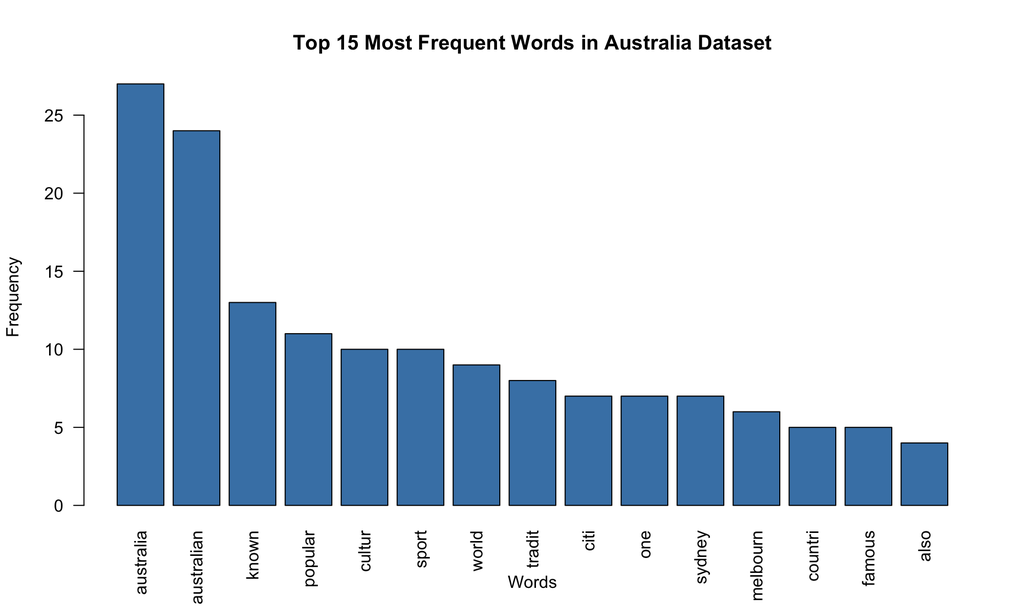

Top 15 Most Frequent Words in Australia Dataset

```r
# Create word frequency plot
top_words <- head(word_freq_df, 15)
barplot(top_words$freq, names.arg = top_words$word,
        main = "Top 15 Most Frequent Words in Australia Dataset",
        xlab = "Words", ylab = "Frequency",
        col = "steelblue", las = 2)
```

# Word Cloud Visualization

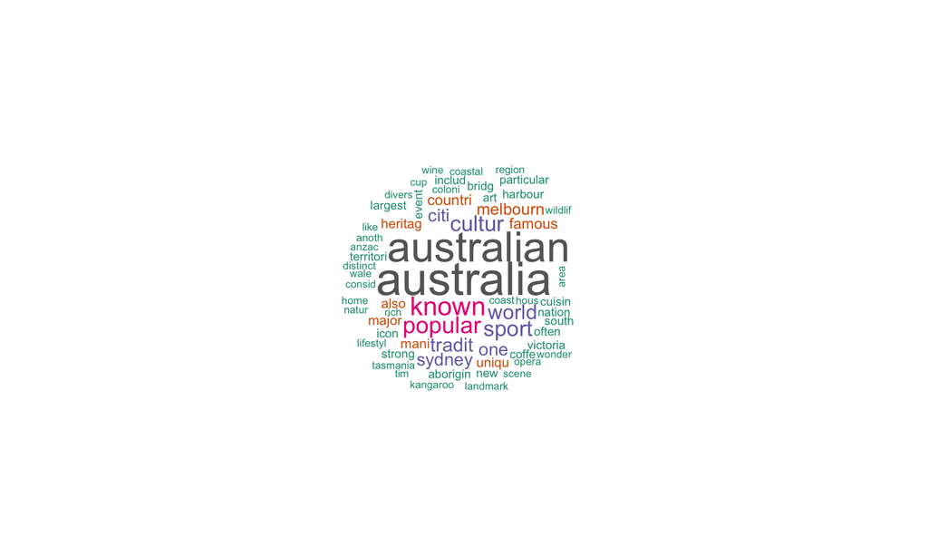

Word Cloud of Most Frequent Terms

```r
# Set seed for reproducibility
set.seed(123)

# Generate word cloud
wordcloud(words = word_freq_df$word, freq = word_freq_df$freq,
          min.freq = 1, max.words = 100,
          random.order = FALSE,
          colors = brewer.pal(8, "Dark2"),
          scale = c(3, 0.5))
```

# Topic Modeling with LDA

Now let’s perform topic modeling using Latent Dirichlet Allocation:

```r
# Set the number of topics
k <- 3

# Fit the LDA model
set.seed(1234)
lda_model <- LDA(dtm, k = k, control = list(seed = 1234))

# Extract topics using tidytext
topics <- tidy(lda_model, matrix = "beta")

# Get top terms for each topic
top_terms <- topics %>%
  group_by(topic) %>%
  top_n(10, beta) %>%
  ungroup() %>%
  arrange(topic, -beta)

cat("Top terms for each topic:\n")
```

```
## Top terms for each topic:
```

```r
print(top_terms)
```

```
## # A tibble: 30 × 3
##    topic term         beta
##    <int> <chr>       <dbl>
##  1     1 australia  0.183
##  2     1 sport      0.0723
##  3     1 australian 0.0709
##  4     1 popular    0.0617
##  5     1 tradit     0.0518
##  6     1 citi       0.0451
##  7     1 cultur     0.0442
##  8     1 one        0.0317
##  9     1 known      0.0276
## 10     1 uniqu      0.0227
## # ℹ 20 more rows
```

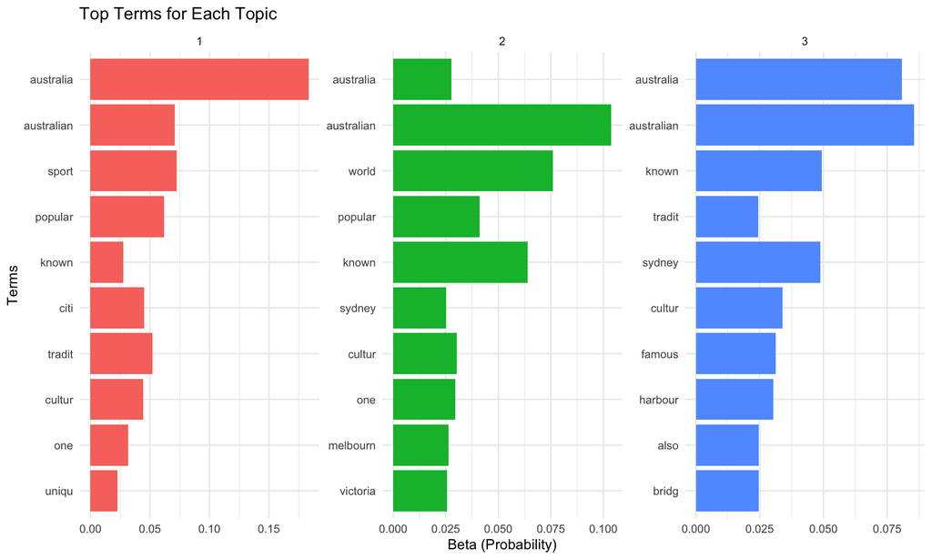

Top Terms for Each Topic

```r
# Create topic visualization
top_terms %>%
  mutate(term = reorder(term, beta)) %>%
  ggplot(aes(term, beta, fill = factor(topic))) +
  geom_col(show.legend = FALSE) +
  facet_wrap(~ topic, scales = "free") +
  coord_flip() +
  labs(title = "Top Terms for Each Topic",
       x = "Terms", y = "Beta (Probability)") +
  theme_minimal() +
  theme(plot.background = element_rect(fill = "white", color = NA),
        panel.background = element_rect(fill = "white", color = NA))
```

# Document-Topic Analysis

Let’s examine how documents are assigned to topics:

```r
# Get document-topic probabilities
doc_topics <- tidy(lda_model, matrix = "gamma")

# Display document-topic assignments
cat("Document-topic probabilities:\n")
```

```
## Document-topic probabilities:
```

```r
print(doc_topics)
```

```
## # A tibble: 21 × 3
##    document                 topic gamma
##    <chr>                    <int> <dbl>
##  1 australian_animals.txt       1 0.333
##  2 australian_cities.txt        1 0.333
##  3 australian_culture.txt       1 0.334
##  4 australian_food.txt          1 0.338
##  5 australian_landmarks.txt     1 0.303
##  6 australian_sports.txt        1 0.352
##  7 README.md                    1 0.342
##  8 australian_animals.txt       2 0.340
##  9 australian_cities.txt        2 0.326
## 10 australian_culture.txt       2 0.337
## # ℹ 11 more rows
```

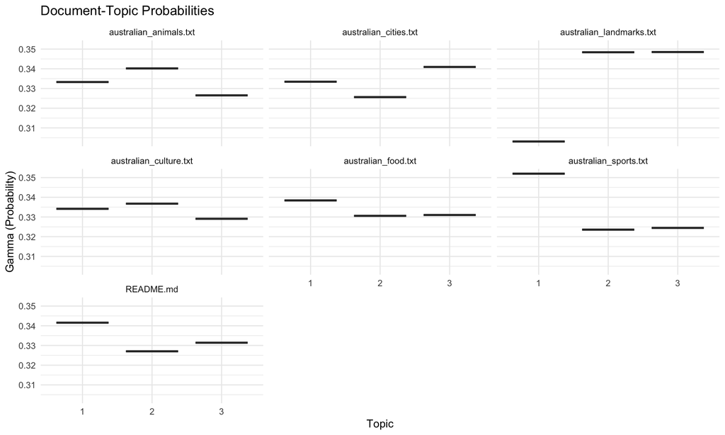

Document-Topic Probabilities

```r
# Create document-topic visualization
doc_topics %>%
  mutate(document = reorder(document, gamma)) %>%
  ggplot(aes(factor(topic), gamma)) +
  geom_boxplot() +
  facet_wrap(~ document) +
  labs(title = "Document-Topic Probabilities",
       x = "Topic", y = "Gamma (Probability)") +
  theme_minimal() +
  theme(plot.background = element_rect(fill = "white", color = NA),
        panel.background = element_rect(fill = "white", color = NA))
```

# Alternative LDA Implementations

Let’s test different numbers of topics to find the optimal configuration:

```r
# Test different numbers of topics
k_values <- c(2, 3, 4, 5)
perplexity_scores <- numeric(length(k_values))

for (i in seq_along(k_values)) {
  set.seed(1234)
  lda_temp <- LDA(dtm, k = k_values[i], control = list(seed = 1234))
  perplexity_scores[i] <- perplexity(lda_temp, dtm)
  cat("K =", k_values[i], "Perplexity =", perplexity_scores[i], "\n")
}
```

```
## K = 2 Perplexity = 35.56882
## K = 3 Perplexity = 45.67536
## K = 4 Perplexity = 45.7237
## K = 5 Perplexity = 45.76267
```

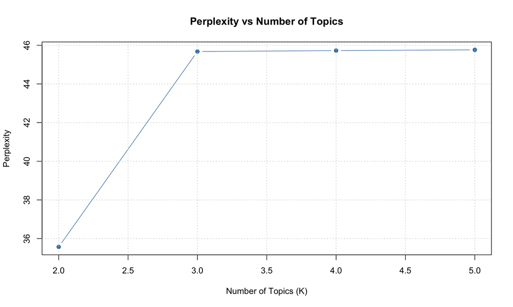

Perplexity vs Number of Topics

```r
# Create perplexity plot
plot(k_values, perplexity_scores, type = "b",
     main = "Perplexity vs Number of Topics",
     xlab = "Number of Topics (K)", ylab = "Perplexity",
     col = "steelblue", pch = 19)
grid()
```

# Results and Interpretation

## Topic Assignments

```r
# Display topic assignments for each document
cat("Topic assignments for each document:\n")
```

```
## Topic assignments for each document:
```

```r
for (i in 1:length(corpus)) {
  doc_name <- names(corpus)[i]
  doc_topic_probs <- doc_topics[doc_topics$document == i, ]
  dominant_topic <- doc_topic_probs$topic[which.max(doc_topic_probs$gamma)]
  cat("Document", i, "(", doc_name, "): Topic", dominant_topic,
      "(probability:", round(max(doc_topic_probs$gamma), 3), ")\n")
}
```

[output not shown]

```
## Document 1 ( australian_animals.txt ): Topic  (probability: -Inf )
```

```
## Document 2 ( australian_cities.txt ): Topic  (probability: -Inf )
```

```
## Document 3 ( australian_culture.txt ): Topic  (probability: -Inf )
```

```
## Document 4 ( australian_food.txt ): Topic  (probability: -Inf )
```

```
## Document 5 ( australian_landmarks.txt ): Topic  (probability: -Inf )
```

```
## Document 6 ( australian_sports.txt ): Topic  (probability: -Inf )
```

```
## Document 7 ( README.md ): Topic  (probability: -Inf )
```

## Summary

```r
cat("=== TOPIC MODELING SUMMARY ===\n")
```

```
## === TOPIC MODELING SUMMARY ===
```

```r
cat("Dataset: Australia Dataset\n")
```

```
## Dataset: Australia Dataset
```

```r
cat("Number of documents:", length(corpus), "\n")
```

```
## Number of documents: 7
```

```r
cat("Number of terms in DTM:", ncol(dtm), "\n")
```

```
## Number of terms in DTM: 64
```

```r
cat("Number of topics (K):", k, "\n")
```

```
## Number of topics (K): 3
```

```r
cat("Total word frequency:", sum(word_freq), "\n")
```

```
## Total word frequency: 277
```

```r
cat("Most frequent word:", word_freq_df$word[1], "(", word_freq_df$freq[1], "times)\n")
```

```
## Most frequent word: australia ( 27 times)
```

# Conclusion

This analysis demonstrates how to:

1. **Preprocess text data** for topic modeling
2. **Analyze word frequencies** to understand the vocabulary
3. **Apply LDA** to discover hidden topics
4. **Visualize results** using various plots
5. **Evaluate model performance** using perplexity

# References

- [Text Mining with R](https://www.tidytextmining.com/topicmodeling)
- Blei, D. M., Ng, A. Y., & Jordan, M. I. (2003). Latent dirichlet allocation. Journal of machine Learning research, 3(Jan), 993-1022.
- Silge, J., & Robinson, D. (2017). Text mining with R: A tidy approach. O’Reilly Media.